# Functions and Datasets

Jason T. Serviss

30/11/2016

# Introduction

This document is to highlight the capability of the functions used for testing the ClusterSignificance package.

# General and specificity/sensitivity testing functions

## Lower level functions

### makeMatrix

```r
help('makeMatrix')
```

| makeMatrix | R Documentation |
| --- | --- |

## Make Matrix

### Description

This function is specifically designed for the generation of 2 groups of points within a matrix.

### Arguments

| `x` | A numerical vector of length 2 specifying the range of values possible for group 1. |
| --- | --- |
| `y` | A numerical vector of length 2 specifying the range of values possible for group 2. |
| `dim` | The number of dimensions (columns) to generate. |
| `points` | The number of data points in each group. |
| `by` | Indicates the frequency of ponts which are subsequently randomly picked according to the *points* argument. |
| `seed` | Sets the seed to make results reproducible. |
| `replace` | Passed to the `sample` function. |
| `…` | Arguments to pass on. |

### Details

Makes a matrix containing data for two groups of points. Specifying a specific number of points, dimensions, and range of points for each group is suported. The resulting matrix will have group 1 occupying the top half of the matrix and group 2 the bottom half.

### Author(s)

Jason Serviss

### Examples

```r
mat <- makeMatrix(x=c(0,1), y=c(0,1), dim=2, points=10)
```

#### Source code

```r
makeMatrix <-
function(
    x,
    y,
    dim,
    points,
    by = 0.001,
    seed = 3,
    replace = FALSE,
    ...
) {
    set.seed(seed)

    #below, a call to sapply facilitates a iteration for each dim
    #for each iteration sample is called twice, one for x and one for y
    #results from the sample calls are concatenated
    #calls to sample randomly pick numbers between the values for x and y
    #the number of points picked by sample is governed by the points argument
    #finally, results from sample calls are formated into a matrix with the expected
    # ClusterSignificance structure.
    mat <- matrix(
        c(
            sapply(1:dim, function(xi)
                c(
                    sample(
                        seq(
                            x[1],
                            x[2],
                            by
                        ),
                        replace=replace,
                        size = points
                    ),
                    sample(
                        seq(
                            y[1],
                            y[2],
                            by
                        ),
                        replace=replace,
                        size = points
                    )
                )
            )
        ), ncol = dim
    )
    output <- list(mat, x, y) #matrix and arguments output
    class(output) <- "makeMatrix" #class assignment to output
    return(output)
}
```

### makeGroups

```r
help('makeGroups')
```

| makeGroups | R Documentation |
| --- | --- |

## Make Groups

### Description

This function makes the `groups` input variable to ClusterSignificance from a `makeMatrix` generated matrix.

### Arguments

| `mat` | The matrix for which the groups should be generated. |
| --- | --- |
| `names` | A character vector indicating the names of the groups. |
| `…` | Arguments to pass on. |

### Details

This function is specifically designed for the generation of the groups argument corresponding to the output from the `makeMatrix` function. It always results in 2 groups with each group being assigned an equal amount of points in the matrix.

### Author(s)

Jason Serviss

### Examples

```r
mat <- makeMatrix(x=c(0,1), y=c(0,1), dim=2, points=10)
groups <- makeGroups(mat, names=c("grp1", "grp2"))
```

```r
makeGroups <-
function(
    mat,
    names,
    ...
) {
    #input checks
    if(length(mat[[1]]) == 1) {
        stop("the matrix you submitted is not properly formated")
    }

    if(length(names) < 2) {
        stop("the names you submitted are < length 2")
    }

    mat <- mat[[1]]

    #below a call to sapply provides iteration over the names argument
    #the names are evenly divided over the rows of the matrix
    #this is done so that the first name gets the first division of rows
    #the second name gets the second division of rows, et.
    groups <- c(
        sapply(
            1:length(names),
            function(ix, iy)
                rep(
                    iy[ix],
                    nrow(mat)/length(names)
                ),
                iy = names
        )
    )
    return(groups)
}
```

### overlapProbability

```r
help(overlapProbability)
```

| overlapProbability | R Documentation |
| --- | --- |

## Overlap Probability Function

### Description

This function generates a table that contains the probability of generating a specific overlap between groups when starting with a specific x value.

### Author(s)

Jason Serviss

### Examples

```r
overlapProbability(save=FALSE, reps=2)
```

```r
overlapProbability <-
function(
    points = 102,
    reps = 30,
    x1 = seq(0, 101, by=1),
    by = 0.9,
    save = TRUE,
    verbose = TRUE
) {
    #below is an example of "left-side variable assignment"
    #i.e. pointsOverlaps is assigned data.frame() and count is assigned 1.
    #syntactic sugar
    g(pointsOverlaps, count) %=% list(data.frame(), 1)

    #the first loop was included with the original thought of having a
    #overlap table with many different points amounts, although, after
    #the realization that not all overlaps can be generated with any points
    #amount, the function was always run with points = 102, due to the fact
    #that all overlaps can be generated with this points amount.
    for(c in points) {
        #set y values and x2 values to static values, only x1 varies
        g(x2, y) %=% list(x1 + 101, c(0, 101))

        if(verbose == TRUE) {message(c)}

        #iterate over the values of x1
        #these values represent all values from y1 to y2.
        #thus x acts like a sliding window over y from, in theory,
        #100 percent overlap of the y range to 0 percent overlap of
        #the y range
        for(i in 1:length(x1)) {

            #make an array to keep track of matrices which have already
            #been tested so they are not tested again
            otherMatrices <- array(
                rep(0, c*2*2*reps),
                dim=c(c*2, 2, reps)
            )

            #iterate over each desired replicate of this x1 value
            for(z in 1:reps) {

                #create the mat and groups variable
                cmag <- .createMatAndGroups(x1, x2, i, y, c, by)
                mat <- cmag[[1]]
                groups <- cmag[[2]]

                #run the matrix tests on the matrix
                #note that if the matrix does not pass one or more of the
                #tests, it is automatically re-generated by the matrixTests
                #function until it passes all tests, at which time, it is
                #returned here.
                mat <- matrixTests(
                    tests=c(
                        "checkIdenticalDims",
                        "checkIdenticalMatrix",
                        "checkIdenticalPoints"
                    ),
                    mat,
                    groups,
                    dim = 2,
                    points = c,
                    by = by,
                    otherMatrices = otherMatrices,
                    idPointsThreshold = 3,
                    verbose = ifelse(verbose == TRUE, TRUE, FALSE)
                )[[1]]

                #add the matrix to the tracking array, explained above
                otherMatrices[,,z] <- mat[[1]]

                #calculate the group overlap percentage for the current matrix
                overlap <- calculateOverlap(
                    mat,
                    groups
                )

                #the .savePointsOverlaps function reformats the data associated
                #with the current matrix for subsequent adding to the output variable
                add <- .savePointsOverlaps(
                    i,
                    c,
                    z,
                    x1,
                    overlap,
                    mat
                )

                #bind the current matrix and its associated data to the output variable
                pointsOverlaps <- rbind(
                    pointsOverlaps,
                    add
                )

                count <- count + 1
            }
        }
    }

    #below we examine, for each x1, which overlap is most commonly generated
    pointsOverlaps$overlap <- round(pointsOverlaps$overlap)

    freq <- plyr::ddply(
       pointsOverlaps,
       c("x1", "overlap"),
       plyr::summarize,
       freq=length(x1)
    )

    #below we extract the x1 with the highest probability for giving a specific overlap
    overlapTable <- plyr::ddply(
       freq,
       "overlap",
       .fun = function(x)
           plyr::summarise(
               x,
               x[which(x$freq == max(x$freq)), 'x1']
           )[1:1,]
    )

    #save the output os so desired
    colnames(overlapTable) <- c("overlap", "x1")

    if(save == TRUE) {
        save(
            overlapTable,
            file = "data/overlapTable.rda",
            compress="bzip2"
        )
    }

    return(overlapTable)
}
```

#### .savepointsOverlaps

```r
.savePointsOverlaps <-
function(
    i,
    c,
    z,
    x1,
    overlap,
    mat
){
    add <- data.frame(
        points = c,
        reps = z,
        x1 = x1[i],
        overlap = overlap,
        mat = I(list(mat)),
        stringsAsFactors = FALSE
    )
    return(add)
}
```

#### .createMatAndGroups

```r
.createMatAndGroups <-
function(x1, x2, i, y, c, by) {
    mat <- makeMatrix(
        x=c(x1[i], x2[i]),
        y=y,
        dim=2,
        points = c,
        by = by
    )

    groups <- makeGroups(
        mat,
        names=c("grp1", "grp2")
    )
    return(list(mat, groups))
}
```

### dynamicXY

```r
help('dynamicXY')
```

| dynamicXY | R Documentation |
| --- | --- |

## Dynamic X and Y setter

### Description

This function allows the dynamic adjustment of X and Y values in the `makeMatrix` function dependant on the desired group overlap. It uses a previously generated table from the `overlapProbability` function. The use of this function allows much faster generation of matrices with a specific group overlap than if the computer were to need to randomly try X and Y values until the overlap was generated. Y values are currently always (0,101) and X2 values are always x1 + 100. Is appropriate only to use when the points argument to `makeMatrix` is 102 and the by argument in 0.9. The returned X and Y values have been optimized to have the highest probability to generate the same overlap in both dimensions of the matrix i.e. when the `makeMatrix` argument `dim` is set to 2.

### Arguments

| `desiredOverlap` | Overlap for which X and Y values should be generated. |
| --- | --- |

### Author(s)

Jason Serviss

### Examples

```r
XY <- dynamicXY(overlapTable, desiredOverlap = 0)
mat <- makeMatrix(XY[[1]], XY[[2]], dim=2, points=102)[[1]]
groups <- makeGroups(mat, names=c("grp1", "grp2"))
calculateOverlap(mat[ ,1], groups) #overlap dimension 1
calculateOverlap(mat[ ,2], groups) #overlap dimension 2
```

```r
dynamicXY <-
function(
    desiredOverlap
){

    #below, y is set to the values used for the calculation of
    #the overlapTable
    yOut <- c(0,101)

    #below, we search the overlapTable for the corresponding
    #x1 value according to the desired overlap sepcified in the
    #desiredOverlap argument
    #x2 always equals x1+100

    ##if handles the situation where a specific x is available
    ##in the table for the desired overlap and that overlap is
    ##not 100

    ##the first else if handles a 100 percent overlap
    ##the 2nd else if handles a 0 percent overlap

    ##else handles the case where the overlap is not found
    if(
        desiredOverlap != 100 &
        desiredOverlap != 0
    ) {
        if(
            nrow(subset(
                overlapTable,
                overlap == desiredOverlap
            )) == 1
        ){
            x1 <- as.numeric(
                subset(
                    overlapTable,
                    overlap == desiredOverlap,
                    select="x1"
                )[1:1,]
            )

            x2 <- x1 + 100
            xOut <- c(x1, x2)
        }

    } else if(desiredOverlap == 100) {

        xOut <- yOut

    } else if(desiredOverlap == 0) {

        xOut <- c(101, 101+100)

    } else {

        stop(
            paste(
                "Could not find entry for ",
                desiredOverlap,
                " in the look-up table",
                sep=""
            )
        )

    }

    return(list(xOut, yOut))
}
```

### addOnePoint

```r
help('addOnePoint')
```

| addOnePoint | R Documentation |
| --- | --- |

## Add data point

### Description

Adds one point to each group in the matrix.

### Arguments

| `mat` | from makeMatrix |
| --- | --- |
| `groups` | from makeGroups |
| `seed` | passed to set.seed |

### Details

This function is designed to add one point in each dimension per group to the current matrix. The points that are added are done so with a call to `makeMatrix` where the `x` and `y` arguments are identical to the origional matrix. The function is primairly designed to work with the `zeroOrHundred` function.

### Author(s)

Jason Serviss

### Examples

```r
mat <- makeMatrix(x=c(0,100), y=c(0, 100), dim=2, points=10)
groups <- makeGroups(mat, names=c("grp1", "gpr2"))
matPlus <- addOnePoint(mat, groups)
```

```r
addOnePoint <-
function(
    mat,
    groups,
    seed = 3
){

    #input check
    if(length(mat[[1]]) == 1){
        stop("the matrix you submitted is not properly formated")
    }

    #extract the matris and the x and y values used to generate it
    m <- mat[[1]]
    x <- mat[[2]]
    y <- mat[[3]]

    #etract the values corresponding to both groups from the matrix
    t <- ifelse(
        groups == unique(groups)[1],
        TRUE,
        FALSE
    )

    m1 <- m[t, ]
    m2 <- m[!t, ]

    #make the points to add to the input matrix
    #utilize the same x and y values as the input matrix
    newPoints <- makeMatrix(
        x=x,
        y=y,
        dim=dim(m)[2],
        points=1,
        seed=seed
    )[[1]]

    #add the new points to the input matrix
    n1 <- rbind(m1, newPoints[1,])
    n2 <- rbind(m2, newPoints[2,])
    mat <- rbind(n1, n2)

    #retrun the results
    out <- list(mat, x, y)
    class(out) <- "makeMatrix"
    return(out)
}
```

## Matrix Checks

### calculateOverlap

```r
help('calculateOverlap')
```

| calculateOverlap | R Documentation |
| --- | --- |

## Calculate Overlap

### Description

Calculate the overlap between two groups.

### Arguments

| `mat` | The numerical vector. |
| --- | --- |
| `groups` | Defines the location of the groups within the vector. |
| `…` | Arguments to pass on. |

### Details

This function accepts a matrix containing data points for 2 groups where group 1 occupies the top half of the matrix and group 2, the bottom half. It calculates and returns the overlap between the 2 groups. *Overlap* in this case, is calculated dependant on the class of the mat argument. If the class of the mat argument is numeric and is one dimension form a `makeMatrix` matrix, then overlap refers to *100 * ((grp 1 points in grp2 range + grp2 points in grp1 range) / total number of points)*. If, on the other hand, the class of mat is *makeMatrix* then the percentage of intersecting area between the two groups is calculated.

### Author(s)

Jason Serviss

### References

https://en.wikipedia.org/wiki/Convex_hull

### Examples

```r
mat <- makeMatrix(x=c(0,1), y=c(1.1,2.1), dim=2, points=20)
groups <- makeGroups(mat, c("g1", "g2"))
calculateOverlap(mat, groups)
```

```r
calculateOverlap <-
function(
    mat,
    groups,
    ...
) {
    #input checks
    if(class(mat) != "makeMatrix" & class(mat) != "numeric"){
        stop("the matrix you submitted is not properly formated")
    }

    if(class(mat) == "numeric") {
        spl <- split(
            mat,
            groups
        )

        #the if statment handles 100 percent overlap, i.e. one group's
        #range is totally contained with the other groups range.

        #else if handles 0 percent overlap, i.e. the range on both
        #groups is not overlapping

        #finally, else handles all other scenerios

        if(
            all(spl[[2]] > min(spl[[1]]) & spl[[2]] < max(spl[[1]])) |
            all(spl[[1]] > min(spl[[2]]) & spl[[1]] < max(spl[[2]]))
        ){
            percent_overlap <- 100
            return(percent_overlap)

        } else if(
            all(spl[[2]] > max(spl[[1]])) |
            all(spl[[1]] > max(spl[[2]]))
        ) {
            percent_overlap <- 0
            return(percent_overlap)

        } else {
            #calculate the number of points from each group within the other
            #groups range as a logical and then as a number
            grp1 <- spl[[1]] > min(spl[[2]]) & spl[[1]] < max(spl[[2]])
            grp2 <- spl[[2]] > min(spl[[1]]) & spl[[2]] < max(spl[[1]])
            total <- c(grp1, grp2)
            count <- length(total[total == TRUE])

            #calculate the percentage of overlap
            percent_overlap <- round(
                (count / length(mat)) * 100
            )

            return(percent_overlap)
        }

    }

    #intersecting are calculation
    #this first uses "convex hulls" to determine a shape for each group
    #after the shape is determined, the intersecting area of the 2 shapes is calculated
    if(class(mat) == "makeMatrix") {
        #make a variable holding the matrix values for each group
        mat <- mat[[1]]
        spl <- split(mat, groups)
        g1 <- matrix(spl[[1]], ncol=2)
        g2 <- matrix(spl[[2]], ncol=2)

        #find the convex hull for each group
        hull1 <- chull(g1)
        hull2 <- chull(g2)

        #use the convex hull to make a polygon representing each group
        p1 <- as(g1[hull1, ], "gpc.poly")
        p2 <- as(g2[hull2, ], "gpc.poly")

        #calculate the area of each polygon
        area1 <- area.poly(p1)
        area2 <- area.poly(p2)

        #find the intersecting area of each polygon and calculate the percentage of overlap
        areaIntersection <- area.poly(intersect(p1,p2))
        percentOverlap <- round(((areaIntersection * 2) / (area1 + area2)) * 100)
    }

    return(percentOverlap)
}
```

### interspersion

```r
help(interspersion)
```

| interspersion | R Documentation |
| --- | --- |

## Calculate interspersion

### Arguments

| `mat` | The mattrix to be checked. Usually a `makeMatrix` matrix. |
| --- | --- |
| `groups` | A character vector indicating the groups location within the matrix. Can be generated with the makeGroups function. Can only accept 2 groups. |
| `dim` | Which dimention of the matrix to check. |

### Author(s)

Jason Serviss

### Examples

```r
mat <- makeMatrix(x=c(0,1), y=c(0,1), dim=2, points=10, seed=15)
groups <- makeGroups(mat, names=c("g1", "g2"))
interspersion(mat, groups, 1)

mat <- makeMatrix(x=c(0,1), y=c(0.9,0.95), dim=2, points=10, seed=15)
groups <- makeGroups(mat, names=c("g1", "g2"))
interspersion(mat, groups, 1)
```

```r
interspersion <-
function(
    mat,
    groups,
    dim
) {
    if(length(mat[[1]]) == 1){
        stop("the matrix you submitted is not properly formated")
    }

    mat <- mat[[1]]
    vector <- mat[, dim]

    l <- length(groups) / 2

    ##max score; this represents 100% interspersion
    ##indexes of grp1 and grp2 alternate every element
    names <- rep(
        c("1", "2"),
        l
    )

    max <- sum(
        which(names == "1")
    ) * sum(
        which(names == "2")
    )

    ##min score; this represents 0% interspersion
    ##indexes of group2 are within one group1 interval
    names <- c(
        "1",
        rep("2", l),
        rep("1", l - 1)
    )

    min <- sum(
        which(names == "1")
    ) * sum(
        which(names == "2")
    )

    ##scale; here i divide range between the min and max possible interspersion into
    ##100 elements. By performing the same calculation with the real data and then seeing
    ##where it falls on the scale, I can determine the "percentage of interspersion".
    s <- seq(
        min,
        max,
        by=(max-min)/100
    )

    ##real score; calculates the real score
    names(vector) <- groups
    g <- unique(groups)
    vector <- sort(vector)

    real <- sum(
        which(names(vector) == g[1])
    ) * sum(
        which(names(vector) == g[2])
    )

    ##score; finds where the real score falls on the scale of the theoretical scale
    score <- which.min(
        abs(s - real)
    ) - 1

    return(score)
}
```

An example of **interspersion**:

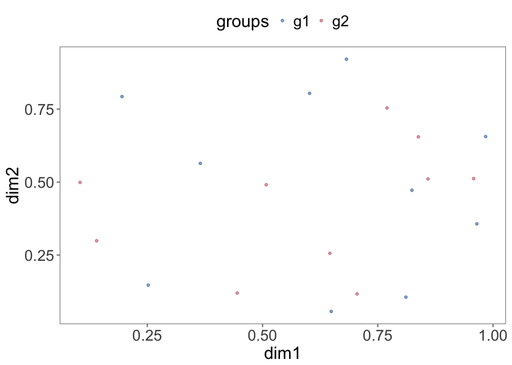

```r
mat <- makeMatrix(x=c(0,1), y=c(0,1), dim=2, points=10, seed=15)
groups <- makeGroups(mat, names=c("g1", "g2"))
visualizeOverlaps(mat, groups, plotType="points")
```

```r
interspersion(mat, groups, 1)
```

```
## [1] 100
```

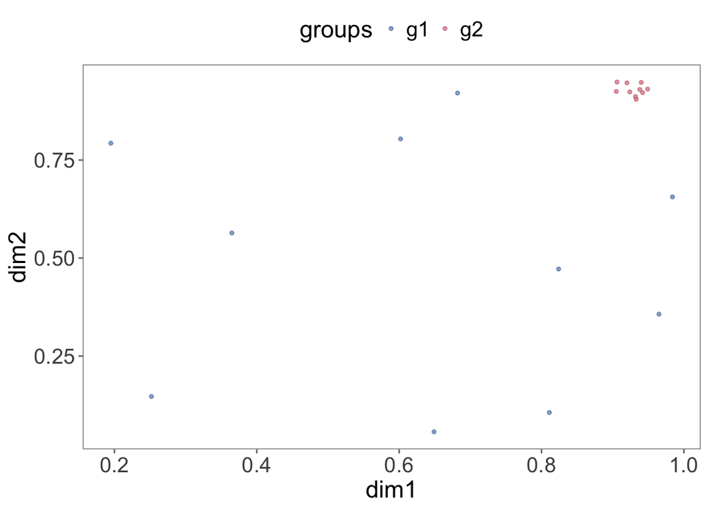

```r
mat <- makeMatrix(x=c(0,1), y=c(0.9,0.95), dim=2, points=10, seed=15)
groups <- makeGroups(mat, names=c("g1", "g2"))
visualizeOverlaps(mat, groups, plotType="points")
```

```r
interspersion(mat, groups, 1)
```

```
## [1] 44
```

We can see that in the first example (left) that group 2 is highly interspersed within group 1 and therefore, the interspersion score is high. On the other hand, in the second example (right) group 2 has a low interspersion within group 1 and, therefore, the interspersion score is low.

### checkIdenticalDims

```r
help('checkIdenticalDims')
```

| checkIdenticalDims | R Documentation |
| --- | --- |

## Check Identical Dimensions

### Description

This function takes an input matrix and checks if any single dimension for a single group is equal to any other single dimension for a single group including itself. For example, with 2 groups with 2 dimensions each, it checks if x dimension for group 1 is exactly equal to dimension y for group 1 or dimension x or y for group 2. **Returns TRUE if none are not identical and FALSE if they are**.

### Arguments

| `mat` | `makeMatrix` function output. |
| --- | --- |
| `groups` | `makeGroups` function output. |
| `ident` | A boolean value. Do not alter. |

### Author(s)

Jason Serviss

### Examples

```r
mat <- makeMatrix(x=c(0,1), y=c(0,1), dim=2, points=10)
groups <- makeGroups(mat, names=c("grp1", "grp2"))
checkIdenticalDims(mat, groups)

mat <- list(matrix(rep(1,40), ncol=2))
groups <- makeGroups(mat, c("grp1", "grp2"))
checkIdenticalDims(mat, groups)
```

```r
checkIdenticalDims <-
function(
    mat,
    groups,
    ident = FALSE
) {

    if(length(mat[[1]]) == 1){
        warning("the matrix you submitted is not properly formated")
    }

    mat <- mat[[1]]

    #subset points in mat corresponding to group 1 and 2 into seperate matrices
    #reformat them into a dataframe with 1 coloum per dimension per group
    g <- ifelse(groups == unique(groups)[1], TRUE, FALSE)
    m1 <- mat[g,]
    m2 <- mat[!g,]
    dat <- data.frame(m1, m2)

    #find all possible combinations of 2 of groups and dimensions
    c <- combn(dat, 2, simplify=FALSE)

    #check if any of the dimensions for any of the groups are equal to any
    #other dimension of any other groups
    bools <- lapply(
        c,
        function(x)
            sapply(
                as.list(x)[-1],
                FUN = setequal,
                as.list(x)[[1]]
            )
    )

    #check that no dimensions are equal to any other dimension
    ident <- all(bools == FALSE)

    return(ident)
}
```

An example of **checkIdenticalDims**:

```r
mat <- makeMatrix(x=c(0,1), y=c(0,1), dim=2, points=10)
names <- c("grp1", "grp2")
groups <- makeGroups(mat, names=names)
checkIdenticalDims(mat, groups)
```

```
## [1] TRUE
```

```r
spl1 <- split(mat[[1]][,1], groups)
spl2 <- split(mat[[1]][,2], groups)
mat <- list(matrix(c(spl1[[1]], spl1[[2]], spl1[[1]], spl2[[2]]), ncol=2))
checkIdenticalDims(mat, groups)
```

```
## [1] FALSE
```

### checkIdenticalMatrix

```r
help('checkIdenticalMatrix')
```

| checkIdenticalMatrix | R Documentation |
| --- | --- |

## Check Identical Matrices

### Description

This function takes an input matrix (mat), typically from `makeMarix`, and an array contaning other matrices (otherMatrices) of the same dimensionality. The function checks if the matrix is identical to any of the other matrices submitted. This was designed for running replicate experiments when each replicate should be unique and is used with the `overlapMatrices`, `overlapProbability`, and `zeroOrHundred` functions.

### Arguments

| `mat` | The matrix to be checked. |
| --- | --- |
| `otherMatrices` | an array of the other matrices to be checked against. |
| `ident` | A boolean value. Do not alter. |

### Author(s)

Jason Serviss

### Examples

```r
mat <- makeMatrix(x=c(0,1), y=c(0,1), dim=2, points=10, seed=11)
otherMatrices <- array(NA, dim=c(20, 2, 1))
otherMatrices[,,1] <- mat[[1]]
checkIdenticalMatrix(mat, otherMatrices)

otherMatrices <- array(NA, dim=c(20, 2, 1))
otherMatrices[,,1] <- makeMatrix(x=c(0,1), y=c(0,1), dim=2, points=10, seed=50)[[1]]
checkIdenticalMatrix(mat, otherMatrices)
```

```r
checkIdenticalMatrix <-
function(
    mat,
    otherMatrices,
    ident = FALSE
) {

    if(length(mat[[1]]) == 1){
        warning("the matrix you submitted is not properly formated")
    }

    mat <- mat[[1]]

    #checks if mat is equal to any matrix in the otherMatrices variable
    bools <- sapply(
        1:dim(otherMatrices)[3],
        function(x)
            all((otherMatrices[,,x] == mat) == TRUE)
    )

    ident <- all(bools == FALSE)

    return(ident)
}
```

### checkIdenticalPoints

```r
help('checkIdenticalPoints')
```

| checkIdenticalPoints | R Documentation |
| --- | --- |

## Check Identical Points

### Description

This function takes an input matrix and checks if, for each group, the frequency of identical data points is greater than what is specified by the *identicalPointsThreshold* argumet. If the number of identical points are less than the identicalPointsThreshold the function returns TRUE and, otherwise, returns FALSE.

### Arguments

| `mat` | a matrix from makeMatrix function. |
| --- | --- |
| `groups` | a character vector from makeGroups function. |
| `dim` | Which dimension of the matrix to check. |
| `identicalPointsThreshold` | Sets the threshold of identical points. |

### Author(s)

Jason Serviss

### Examples

```r
mat <- makeMatrix(x=c(0,1), y=c(0,1), dim=2, points=10, seed=11)
groups <- makeGroups(mat, names=c("grp1", "grp2"))
checkIdenticalPoints(mat, groups, 1, 2)

mat <- list(rbind(mat[[1]], mat[[1]][20,], mat[[1]][20,]))
groups <- makeGroups(mat, c("g1", "g2"))
checkIdenticalPoints(mat, groups, 1, 2)
```

### matrixTests

```r
help('matrixTests')
```

| matrixTests | R Documentation |
| --- | --- |

## Matrix Tests

### Description

A wrapper for all matrix checks. The function also handles “regeneration”, i.e. if a matrix does **not** pass the checks that it should, it is regenerated until it does. Which tests should be run is controled by the `tests` arguement.

### Arguments

[output not shown]

### Author(s)

Jason Serviss

```r
matrixTests <-
function(
    tests = "all",
    mat,
    groups,
    dim = ncol(mat[[1]]),
    points = nrow(mat)/2,
    by = 0.9,
    seed = 3,
    otherMatrices = "",
    desiredOverlap = "",
    interspersionThreshold = "",
    idPointsThreshold = "",
    verbose = FALSE
) {

    if(is.numeric(desiredOverlap)) {
        XY <- dynamicXY(desiredOverlap)
        x <- XY[[1]]
        y <- XY[[2]]
    } else {
        x <- mat[[2]]
        y <- mat[[3]]
    }

    iterations = 0

    #the while loop below runs the desired tests and checks that the input matrix passes all tests
    #at 2 points, the input matrix is checked to see if it has passed the tests thus far, if not
    #a new matrix is generated (with the .regenerate funciton) and the tests are re-run. Once the
    #matrix passes all tests it is returned.
    while(TRUE) {
        testOutput <- list()

        if(verbose == TRUE) {
            print(paste("XY:", x, y, sep=" "))
        }

        #run identical dimensions test
        if("checkIdenticalDims" %in% tests | "all" %in% tests) {
            testOutput <- c(testOutput, checkIdenticalDims(mat, groups))
            if(verbose == TRUE) {
                print(paste("checkIdenticalDims: ", checkIdenticalDims(mat, groups), sep=""))
            }
        }

        #run identical matrix test
        if("checkIdenticalMatrix" %in% tests | "all" %in% tests) {
            testOutput <- c(testOutput, checkIdenticalMatrix(mat, otherMatrices))
            if(verbose == TRUE) {
                print(paste("checkIdenticalMatrix: ", checkIdenticalMatrix(mat, otherMatrices), sep=""))
            }
        }

        #checks if the matrix has passed all tests thus far and, if not, regenerates the matrix
        if(any(testOutput == FALSE)) {
            new <- .regenerate(x, y, dim, points, by, seed, verbose)
            mat <- new[[1]]
            groups <- new[[2]]
            seed <- new[[3]]
            iterations <- iterations + 1
            next
        }

        #check the group overlap in the current matrix
        if("overlapSpecificMatrix" %in% tests | "all" %in% tests) {
            overlap1 <- calculateOverlap(mat[[1]][,1], groups)
            overlap2 <- calculateOverlap(mat[[1]][,2], groups)

            testOutput <- c(testOutput, overlap1 == desiredOverlap & overlap2 == desiredOverlap)

            if(verbose == TRUE) {
                print(paste("overlaps:", overlap1, overlap2, sep=" "))
            }
        }

        #run the interspersion test
        if("interspersion" %in% tests | "all" %in% tests) {
            intValues <- numeric()
            for(i in 1:dim) {
                int <- interspersion(mat, groups, i)
                intValues <- c(intValues, int)
            }
            testOutput <- c(testOutput, all(intValues > interspersionThreshold))
            if(verbose == TRUE) {
                print(paste("interspersion: ", intValues, sep=""))
            }
        }

        #run the check identical points test
        if("checkIdenticalPoints" %in% tests | "all" %in% tests) {
            idPoints <- logical()
            for(q in 1:dim){
                ident <- checkIdenticalPoints(mat, groups, q, idPointsThreshold)
                idPoints <- c(idPoints, ident)
            }
            testOutput <- c(testOutput, all(idPoints == TRUE))
            if(verbose == TRUE) {
                print(paste("checkIdenticalPoints: ", ident, sep=""))
            }
        }

        #if the matrix passes all tests break the while loop
        if(all(testOutput == TRUE)) {
            if(verbose == TRUE){print("complete")}
            break
        }

        if(verbose == TRUE) {
            print(paste("testOutput", testOutput, sep=": "))
        }

        ##if the matrix didn't pass all tests, generate a new matrix
        new <- .regenerate(x, y, dim, points, by, seed, verbose)
        mat <- new[[1]]
        groups <- new[[2]]
        seed <- new[[3]]
        iterations <- iterations + 1
    }

    return(list(mat, groups, otherMatrices, desiredOverlap, dim, points, by, seed, iterations))
}
```

#### .regenerate

```r
.regenerate <-
function(x, y, dim, points, by, seed, verbose) {
    if(verbose == TRUE){print("re-generating")}
    seed <- seed + 1

    mat <- makeMatrix(
        x = x,
        y = y,
        dim = dim,
        points = points,
        by = by,
        seed = seed
    )

    groups <- makeGroups(
        mat,
        names = paste("grp", 1:dim, sep="")
    )

    return(list(mat, groups, seed))
}
```

## Higher level functions

### overlapMatrices

```r
help('overlapMatrices')
```

| overlapMatrices | R Documentation |
| --- | --- |

## Overlap Specific Matrices

### Description

Generates matrices where the groups have a specific percentage of overlap with each other.

### Arguments

| `reps` | The desired number of overlap specific matrices to generate for each overlap. |
| --- | --- |
| `overlaps` | A numerical vector containing all of the overlaps to be generated. |
| `dim` | The number of dimensions (columns) to generate. Passed to the makeMatrix function. |
| `points` | The number of data points in each group. Passed to the makeMatrix function. |
| `by` | Passed to the `makeMatrix` function. |
| `verbose` | Should the function be verbose? |
| `save` | Should output be saved? |

### Details

The function generates overlap specific matrices. It can do this either for a specific overlap or many at once. It is also capable of generating replicates for a single overlap value. All matrices must pass multiple tests before they are accepted with which tests they must pass being dependant on the desired overlap. This function has only been tested with the `dim`, `points`, and `by` values set to their defaults as it utilizes the `overlapProbability` output and the `dynamicXY` function.

### Author(s)

Jason Serviss

### Examples

```r
matrices <- overlapMatrices(reps=2, overlaps=0, dim=2, points=10, save=FALSE, verbose=FALSE)
```

```r
overlapMatrices <-
function(
    reps = 10,
    overlaps = seq(0,100, by=10),
    dim = 2,
    points = 102,
    by = 0.9,
    verbose = TRUE,
    save = TRUE,
    ...
) {

    #setup a empty array to hold the data
    multiplyMatrix <- array(
        NA,
        dim=c(
            points*2,
            dim,
            reps * length(overlaps)
        )
    )

    dimnames(multiplyMatrix)[[3]] <- paste(
        sort(
            rep(
                overlaps,
                reps
            )
        ),
        1:reps,
        sep="."
    )

    #run a iteration for each of the desired overlaps
    for(y in overlaps) {

        if(verbose == TRUE) {message(y)}

        ##make otherMatrices variable for this y
        ##the otherMatrices variable keeps track of previously generated matrices
        ##it is fed into the matrix tests which checks to make sure
        ##that no matrices in different reprtitions are identical.
        otherMatrices <- array(
            0,
            dim=c(
                points*2,
                dim,
                reps
            )
        )

        #run one iteration for each repetition
        for(i in 1:reps) {

            #make the mat and group input
            mat <- makeMatrix(
                x=c(0,0),
                y=c(0,0),
                dim=dim,
                points=points,
                replace=TRUE
            )

            groups <- makeGroups(
                mat,
                paste(
                    "grp",
                    1:dim,
                    sep=""
                )
            )

            #specify which tests should be performed on the matrix and perform them
            #if the desired overlap is 100, additional tests are added
            #otherwise the "standard" tests are used
            #note that if the matrix does NOT pass one or more of the tests a new
            #matrix is generated within the testing function and re-tested and that
            #this is repeated until the matrix passes all tests, then it is returned here
            if(y==100){
                tests <- "all"
                interspersionThreshold <- 50
            } else {
                tests <- c(
                    "checkIdenticalDims",
                    "checkIdenticalMatrix",
                    "overlapSpecificMatrix",
                    "checkIdenticalPoints"
                )
                interspersionThreshold <- ""
            }

            mat2 <- matrixTests(
                tests = tests,
                mat = mat,
                groups = groups,
                dim = dim,
                points = points,
                by = by,
                otherMatrices = otherMatrices,
                desiredOverlap = y,
                interspersionThreshold = interspersionThreshold,
                idPointsThreshold = 3,
                verbose=FALSE
            )


            ##collect matrixes for this overlap in an array
            #as mentioned above, this tracking is used to make sure that
            #matrices in different repetitions are not identical
            otherMatrices[,,i] <- mat2[[1]][[1]]

            ##cache the generated matrix for subsequent return
            multiplyMatrix[,,paste(y,i,sep=".")] <- mat2[[1]][[1]]
        }
    }

    #save the results if so desired
    if(save == TRUE) {
        overlapMatrixData <- multiplyMatrix
        save(
            overlapMatrixData,
            file="data/overlapMatrixData.rda",
            compress="bzip2"
        )
    }

    return(list(multiplyMatrix))
}
```

### zeroOrHundred

```r
help('zeroOrHundred')
```

| zeroOrHundred | R Documentation |
| --- | --- |

## Zero or Hundred Matrix

### Description

Creates the *zero* or *hundred* dataset.

### Arguments

| `overlap` | The desired numerical overlap to be generated. Can be either 0 or 100. |
| --- | --- |
| `dim` | The number of desired spatial dimensions for each groups points to occupy. |
| `reps` | The number of times a dataset for a specific number of points should be generated. |
| `p` | The interval of points per group for which datasets should be generated. |
| `verbose` | Logical indicating if the program should report status updates. |
| `save` | Logical indicating if the output should be saved to the data folder of the current directory. |

### Details

Creates one of two datasets; one where the 2 groups have 0 percent overlap with each other or one where the two groups have 100 percent overlap with each other. 0 percent, in this context, is defined as no datapoints from one group occupy the same space as the points of the other group. 100 percent overlap is defined as one group completley containing the other group within the space that it occupies. For ClusterSignificance testing this function was run with the default paramaters for overlaps 0 and 100.

### Author(s)

Jason Serviss

### Examples

```r
zeroOrHundred(overlap=0, reps=2, p=5:6, save=FALSE)
```

```r
zeroOrHundred <-
function(
    overlap,
    dim = 2,
    reps = 10,
    p = 5:100,
    verbose = TRUE,
    checksVerbose = FALSE,
    save=TRUE
) {

    #get the x and y arguments for makeMatrix depending on the overlap argument
    start <- dynamicXY(
        desiredOverlap = overlap
    )
    x <- start[[1]]
    y <- start[[2]]

    output <- list()
    previousPoints <- array(NA, dim=c((min(p)*2), dim, reps))
    seed <- 3

    #one iteration for each points amount
    for(i in p) {
        if(verbose == TRUE){print(paste("points: ", i, sep=""))}

        #for the first points amount (i=5) "seed matrices"
        #are made using the overlapMatrices function.
        #For each additional, points amount, instead of
        #creating a totally new matrix, values are added to
        #the seed matrices.
        if(i == min(p)){

            otherMatrices <- overlapMatrices(
                reps=reps,
                overlaps=overlap,
                dim=2,
                points=i,
                save=FALSE,
                verbose=FALSE
            )[[1]]

            dimnames(otherMatrices) <- NULL

        } else {

            #get the matrices corresponding to the previous points amount value so they
            #can be added to.
            previousPoints <- output[[i-5]]
            otherMatrices <- array(0, dim=c(i*2, dim, reps))

            #run one iteration per points amount replicate
            for(j in 1:reps){
                if(verbose == TRUE) {print(paste("rep: ", j, sep=""))}

                #extract the matrix for the corresponding replicate with the previous points amount
                #generate corresponding groups variable
                mat <- previousPoints[,,j]
                groups1 <- makeGroups(list(mat), names=c("grp1", "grp2"))
                mat <- list(mat, x, y)

                ##add points to the matrix corresponding to the
                #previous points amount so that it contains
                #the number of points corresponding to the
                #current points amount.
                #run checks, if the checks are ok, continue, otherwise,
                #generate different points and re-check
                while(TRUE) {

                    mat1 <- addOnePoint(mat, groups1, seed)
                    groups2 <- makeGroups(mat1, names=c("grp1", "grp2"))

                    if(overlap == 100){
                        tests <- "all"
                        interspersionThreshold <- 50
                    } else {
                        tests <- c(
                            "checkIdenticalDims",
                            "checkIdenticalMatrix",
                            "overlapSpecificMatrix",
                            "checkIdenticalPoints"
                        )
                    }

                    checks <- matrixTests(
                        tests = tests,
                        mat = mat1,
                        groups = groups2,
                        dim = dim,
                        points = i,
                        by = 0.9,
                        seed = seed,
                        otherMatrices = otherMatrices,
                        desiredOverlap = overlap,
                        interspersionThreshold = interspersionThreshold,
                        idPointsThreshold = 1,
                        verbose = ifelse(checksVerbose == TRUE, TRUE, FALSE)
                    )[[9]]

                    if(checks == 0) {break}
                    seed <- seed + 1
                }
                #add this repitition to the otherMatrices variable
                otherMatrices[,,j] <- mat1[[1]]
            }
        }
        #name and add all the matrices corresponding to the
        #current points amount to the output variable
        dimnames(otherMatrices)[[3]] <- paste(1:reps, "repitition", sep=".")
        output[[i-4]] <- otherMatrices
    }

    #give the output variable meaningful names and save
    names(output) <- paste(p, "points", sep=".")

    if(save == TRUE & overlap == 0) {
        zero <- output
        save(
            zero,
            file="data/zero.rda",
            compress="bzip2"
        )
    }

    if(save == TRUE & overlap == 100) {
        hundred <- output
        save(
            hundred,
            file="data/hundred.rda",
            compress="bzip2"
        )
    }
    return(output)
}
```

### sensivitityTest

```r
help('sensitivityTest')
```

| sensitivityTest | R Documentation |
| --- | --- |

## Sensitivity test

### Arguments

| `interval` | The interval of points amounts that should be tested. i.e. 1 tests points amounts `1:100`, 10 tests `seq(1, 100, 10)`, etc. |
| --- | --- |
| `iterations` | The number of iterations for each call to `permute`. |
| `cores` | The number of cores the test should be parallalized with. |
| `save` | Should the output be saved? |
| `verbose` | Should the function be verbose? |
| `outPath` | The location the file should be saved to if `save=TRUE`. |

### Author(s)

Jason Serviss

### Examples

```r
sensitivityTest(interval=50, iterations=1, cores=1, save=FALSE)
```

```r
sensitivityTest <-
function(
    interval = 1,
    iterations = 10000,
    cores = 4,
    save=TRUE,
    verbose=TRUE,
    outPath='data'
) {
    output <- data.frame()
    tests <- seq(5, 100, 1)
    tests <- subset(tests, tests %% interval == 0)

    for(jj in 1:length(tests)) {

        if(verbose == TRUE) {print(paste("points: ", tests[jj], sep=""))}

        test <- paste(tests[jj], "points", sep=".")
        data(zero)
        pointsArray <- zero[[test]]

        pointsAmount <- gsub(
            "([0-9]*).*",
            "\\1",
            names(zero[test])
        )

        repitition <- gsub(
            "([0-9]*).*",
            "\\1",
            dimnames(pointsArray)[[3]]
        )

        for(yy in 1:dim(pointsArray)[3]) {
            if(verbose == TRUE) {print(paste("reps: ", yy, sep=""))}

            mat <- list(pointsArray[,,yy])
            groups <- makeGroups(mat, paste("grp", 1:2, sep=""))

            if(verbose == TRUE) {print("Pcp")}

            permMat <- permMatrix(mat[[1]], groups, iterations)

            permutePcp <- parallelCS(
                mat = mat[[1]],
                groups = groups,
                iter = iterations,
                projmethod="pcp",
                cores = cores,
                user.permutations = permMat
            )

            pPcp <- pvalue(permutePcp)

            tmp <- data.frame(
                points = pointsAmount,
                rep = repitition[yy],
                pValuePcp = pPcp
            )

            output <- rbind(output, tmp)
        }
    }
    rownames(output) <- 1:nrow(output)

    if(save == TRUE) {
        sensitivityTestResults <- output
        save(
            sensitivityTestResults,
            file=paste(outPath, "sensitivityTest.rda", sep="/"),
            compress="bzip2"
        )
    }
    return(output)
}
```

### specificityTest

```r
help('specificityTest')
```

| specificityTest | R Documentation |
| --- | --- |

## Specificity test

### Description

This function performs the specificity test. This test is designed to determine the true negative rate of the Pcp method. To do this we utilize the hundred dataset which was derived using the `zeroOrHundred` function with argument `overlap`=100. The dataset includes matrices where the group’s range overlap is 100 seperations should be found with Pcp. For each matrice, the permute function is run, using the Pcp method afterwhich, the resulting pvalue is recorded.

### Arguments

| `interval` | The interval of points amounts that should be tested. i.e. 1 tests points amounts `1:100`, 10 tests `seq(1, 100, 10)`, etc. |
| --- | --- |
| `iterations` | The number of iterations for each call to `permute`. |
| `cores` | The number of cores the test should be parallalized with. |
| `save` | Should the output be saved? |
| `verbose` | Should the function be verbose? |
| `outPath` | The location the file should be saved to if `save=TRUE`. |

### Author(s)

Jason Serviss

### Examples

```r
specificityTest(interval=50, iterations=1, cores=1, save=FALSE)
```

```r
specificityTest <-
function(
    interval = 1,
    iterations = 10000,
    cores = 4,
    save=TRUE,
    verbose = TRUE,
    outPath = 'data'
) {
    output <- data.frame()
    tests <- seq(5, 100, 1)
    tests <- subset(tests, tests %% interval == 0)

    for(jj in 1:length(tests)) {

        if(verbose == TRUE) {print(paste("points: ", tests[jj], sep=""))}

        test <- paste(tests[jj], "points", sep=".")
        pointsArray <- hundred[[test]]

        pointsAmount <- gsub(
            "([0-9]*).*",
            "\\1",
            names(hundred[test])
        )

        repitition <- gsub(
            "([0-9]*).*",
            "\\1",
            dimnames(pointsArray)[[3]]
        )

        for(yy in 1:dim(pointsArray)[3]) {
            if(verbose == TRUE) {print(paste("reps: ", yy, sep=""))}

            mat <- list(pointsArray[,,yy])
            groups <- makeGroups(mat, paste("grp", 1:2, sep=""))

            if(verbose == TRUE) {print("Pcp")}

            permMat <- permMatrix(mat[[1]], groups, iterations)

            permutePcp <- parallelCS(
                mat = mat[[1]],
                groups = groups,
                iter = iterations,
                projmethod="pcp",
                cores = cores,
                user.permutations = permMat
            )

            pPcp <- pvalue(permutePcp)

            tmp <- data.frame(
                points = pointsAmount,
                rep = repitition[yy],
                pValuePcp = pPcp
            )

            output <- rbind(output, tmp)
        }
    }
    rownames(output) <- 1:nrow(output)

    if(save == TRUE) {
        specificityTestResults <- output
        save(
            specificityTestResults,
            file=paste(outPath, "specificityTest.rda", sep="/"),
            compress="bzip2"
        )
    }
    return(output)
}
```

# Hematological cancers functions

## Download and analysis functions

### hematologicalCancers

```r
help('hematologicalCancers')
```

| hematologicalCancers | R Documentation |
| --- | --- |

## Hematological Cancers

### Description

Downloads, processes, clusters, and runs ClusterSignificance on the hematological malagnancies dataset.

### Arguments

| `…` | Arguments to pass on. |
| --- | --- |

### Author(s)

Jason Serviss

### Examples

```r
hematologicalCancers()
```

```r
hematologicalCancers <-
function(...) {

    tmp <- .downloadAndProcessData()
    exp <- tmp[[1]]
    pheno <- tmp[[2]]

    exp <- .annotateBiotypes(exp)
    nc <- .filterLongNonCoding(exp)
    lncGenes <- nc$ensembl_gene_id
    pheno <- .renamePhenos(pheno)
    plot <- .runTsne(nc, pheno)

    tmp <- .runPcp()
    mat <- tmp[[1]]
    groups <- tmp[[2]]
    prj <- tmp[[3]]
    group.color <- tmp[[4]]

    #plot, group.color needed for t-sne plots
    #prj needed for projection plots

    cl <- classify(prj)

    #cl needed for classification plots

    pe <- permute(mat, groups, iter=10000, projmethod="pcp")
    pValues <- as.data.frame(pvalue(pe))
    colnames(pValues) <- "pValue"

    #pValues needed for pValue table

    return(list(plot, group.color, prj, cl, pe, pValues, mat, groups, nc, lncGenes))

}
```

#### .downloadAndProcessData

```r
.downloadAndProcessData <-
function() {
    gset <- getGEO("GSE13159", GSEMatrix =TRUE)[[1]]

    #extract expression values, remove incomplete cases, and get phenotype data
    fvarLabels(gset) <- make.names(fvarLabels(gset))
    ex <- as.data.frame(exprs(gset))
    exp <- ex[complete.cases(ex),]
    pheno <- pData(phenoData(gset))

    return(list(exp, pheno))
}
```

#### .annotateBiotypes

```r
.annotateBiotypes <-
function(exp) {

    ensembl = biomaRt::useMart(
        biomart = "ENSEMBL_MART_ENSEMBL",
        dataset="hsapiens_gene_ensembl",
        host = "jul2015.archive.ensembl.org"
    )

    affyids = rownames(exp)

    IDs <- biomaRt::getBM(
        attributes=c(
            'affy_hg_u133_plus_2',
            'ensembl_gene_id',
            'external_gene_name',
            'chromosome_name',
            'start_position',
            'end_position',
            'gene_biotype'
        ),
        filters = 'affy_hg_u133_plus_2',
        values = affyids,
        mart = ensembl
    )

    colnames(IDs) = c(
        "probe_id",
        "ensembl_gene_id",
        "external_gene_name",
        "chromosome_name",
        "start_position",
        "end_position",
        "gene_biotype"
    )

    #remove probes that are duplicated if any
    IDs = subset(
        IDs,
        duplicated(IDs$probe_id) == FALSE &
        duplicated(IDs$probe_id, fromLast=TRUE) == FALSE
    )

    #merge annotation with expression data and extract lncRNA biotypes
    exp <- merge(exp, IDs, by.x=0, by.y="probe_id")

    return(exp)
}
```

#### .filterLongNonCoding

```r
.filterLongNonCoding <-
function(exp) {
    #specify long non-coding
    ncGenes <- c(
        "3prime_overlapping_ncrna",
        "antisense",
        "IG_V_pseudogene",
        "lincRNA",
        "misc_RNA",
        "polymorphic_pseudogene",
        "processed_pseudogene",
        "processed_transcript",
        "pseudogene",
        "sense_intronic",
        "sense_overlapping",
        "TR_V_pseudogene",
        "transcribed_processed_pseudogene",
        "transcribed_unitary_pseudogene",
        "transcribed_unprocessed_pseudogene",
        "unitary_pseudogene",
        "unprocessed_pseudogene"
    )

    #extract long non-coding
    nc <- exp[exp$gene_biotype %in% ncGenes, ]
    rownames(nc) <- nc$Row.names
    nc$Row.names <- NULL
    return(nc)
}
```

#### .renamePhenos

```r
.renamePhenos <-
function(pheno) {
    #change names of genetic subtypes to something more readable
    pheno$characteristics_ch1.1 <- gsub(
        "leukemia class: (.*)",
        "\\1",
        pheno$characteristics_ch1.1
    )

    #concatenate genetic subtypes into their respective cancer types
    #this is done due to the fact that, if the individual genetic subtypes were retained, ClusterSignificance would need to make 153 comparisons instead of 21.
    #153 comparisons is way too many for the publication and will provide a overwhelming amount of results, potentially being hard to interpret.

    Ball <- c("ALL with hyperdiploid karyotype", "ALL with t(1;19)", "ALL with t(12;21)", "c-ALL/Pre-B-ALL with t(9;22)", "c-ALL/Pre-B-ALL without t(9;22)", "mature B-ALL with t(8;14)", "Pro-B-ALL with t(11q23)/MLL")
    aml <- c("AML complex aberrant karyotype", "AML with inv(16)/t(16;16)", "AML with normal karyotype + other abnormalities", "AML with t(11q23)/MLL", "AML with t(15;17)", "AML with t(8;21)")


    pheno$characteristics_ch1.1 <- ifelse(
        pheno$characteristics_ch1.1 %in% Ball,
        "B-ALL",
        ifelse(
            pheno$characteristics_ch1.1 %in% aml,
            "AML",
            ifelse(
                pheno$characteristics_ch1.1 == "T-ALL",
                "T-ALL",
                ifelse(
                    pheno$characteristics_ch1.1 == "Non-leukemia and healthy bone marrow",
                    "Non-leukemia and healthy bone marrow",
                    ifelse(
                        pheno$characteristics_ch1.1 == "CML",
                        "CML",
                        ifelse(
                            pheno$characteristics_ch1.1 == "CLL",
                            "CLL",
                            "MDS"
                        )
                    )
                )
            )
        )
    )

    pheno$characteristics_ch1.1 <- ifelse(
        pheno$characteristics_ch1.1 == "Non-leukemia and healthy bone marrow",
        "normal",
        pheno$characteristics_ch1.1
    )

    return(pheno)
}
```

#### .runTsne

```r
.runTsne <-
function(nc, pheno) {
    tsne <- Rtsne(t(
        nc[ ,!colnames(nc) %in% c(
            "Row.names",
            "probe_id",
            "ensembl_gene_id",
            "external_gene_name",
            "chromosome_name",
            "start_position",
            "end_position",
            "gene_biotype"
        )]
    ), dims=3)

    #put tSNE results and phenotype data in a data.frame
    plot <- data.frame(tsne$Y, pheno)
    retunr(plot)
}
```

#### .runPcp

```r
.runPcp <-
function(plot) {
    mat <- as.matrix(plot[ ,c("X1", "X2", "X3")])
    groups <- plot$characteristics_ch1.1
    prj <- pcp(mat, groups)
    group.color <- getData(prj, "group.color")
    return(list(mat, groups, prj, group.color))
}
```

## Plotting functions

### tsnePlots

```r
help('tsnePlots')
```

| tsnePlots | R Documentation |
| --- | --- |

## tSNE plots

### Description

Performs the tSNE plots for the hematological malagnancies dataset.

### Arguments

| `…` | Arguments to pass on. |
| --- | --- |

### Author(s)

Jason Serviss

### Examples

```r
#tsnePlots()
```

```r
tsnePlots <-
function(plot, dim) {
    mat <- as.matrix(plot[ ,c("X1", "X2", "X3")])
    groups <- plot$characteristics_ch1.1
    prj <- pcp(mat, groups)
    group.color <- getData(prj, "group.color")

    if(dim == "X") {
        .dimX(plot, group.color, groups)
    } else if(dim == "Y") {
        .dimY(plot, group.color, groups)
    } else if(dim == "Z") {
        .dimZ(plot, group.color, groups)
    } else {
        stop("The specified dim could not be found.")
    }
}
```

#### .dimX

```r
.dimX <-
function(plot, group.color, groups) {
    p <- scatterplot3d(
        plot[plot$characteristics_ch1.1 == colnames(group.color)[1], "X1"],
        plot[plot$characteristics_ch1.1 == colnames(group.color)[1], "X2"],
        plot[plot$characteristics_ch1.1 == colnames(group.color)[1], "X3"],
        color=rgb(
            group.color["red",   colnames(group.color)[1]],
            group.color["green", colnames(group.color)[1]],
            group.color["blue",  colnames(group.color)[1]],
            150,
            maxColorValue=255
        ),
        pch=16,
        box=FALSE,
        xlab="X",
        ylab="Y",
        zlab="Z",
        xlim=c(min(plot$X1), max(plot$X1)),
        ylim=c(min(plot$X2), max(plot$X2)),
        zlim=c(min(plot$X3), max(plot$X3))

    )

    invisible(
        sapply(2:length(unique(groups)), function(x)
            p$points3d(
                plot[plot$characteristics_ch1.1 == colnames(group.color)[x], "X1"],
                plot[plot$characteristics_ch1.1 == colnames(group.color)[x], "X2"],
                plot[plot$characteristics_ch1.1 == colnames(group.color)[x], "X3"],
                col=rgb(
                    group.color["red",   colnames(group.color)[x]],
                    group.color["green", colnames(group.color)[x]],
                    group.color["blue",  colnames(group.color)[x]],
                    150,
                    maxColorValue=255
                ),
                pch=16,
                cex = 1
            )
        )
    )
}
```

#### .dimY

```r
.dimY <-
function(plot, group.color, groups) {
    p <- scatterplot3d(
        plot[plot$characteristics_ch1.1 == colnames(group.color)[1], "X2"],
        plot[plot$characteristics_ch1.1 == colnames(group.color)[1], "X1"],
        plot[plot$characteristics_ch1.1 == colnames(group.color)[1], "X3"],
        color=rgb(
            group.color["red",   colnames(group.color)[1]],
            group.color["green", colnames(group.color)[1]],
            group.color["blue",  colnames(group.color)[1]],
            150,
            maxColorValue=255
        ),
        pch=16,
        box=FALSE,
        xlab="Y",
        ylab="X",
        zlab="Z",
        xlim=c(min(plot$X2), max(plot$X2)),
        ylim=c(min(plot$X1), max(plot$X1)),
        zlim=c(min(plot$X3), max(plot$X3))
    )

    invisible(
        sapply(2:length(unique(groups)), function(x)
            p$points3d(
                plot[plot$characteristics_ch1.1 == colnames(group.color)[x], "X2"],
                plot[plot$characteristics_ch1.1 == colnames(group.color)[x], "X1"],
                plot[plot$characteristics_ch1.1 == colnames(group.color)[x], "X3"],
                col=rgb(
                    group.color["red",   colnames(group.color)[x]],
                    group.color["green", colnames(group.color)[x]],
                    group.color["blue",  colnames(group.color)[x]],
                    150,
                    maxColorValue=255
                ),
                pch=16,
                cex = 1
            )
        )
    )
}
```

#### .dimZ

```r
.dimZ <-
function(plot, group.color, groups) {
    p <- scatterplot3d(
        plot[plot$characteristics_ch1.1 == colnames(group.color)[1], "X3"],
        plot[plot$characteristics_ch1.1 == colnames(group.color)[1], "X2"],
        plot[plot$characteristics_ch1.1 == colnames(group.color)[1], "X1"],
        color=rgb(
            group.color["red",   colnames(group.color)[1]],
            group.color["green", colnames(group.color)[1]],
            group.color["blue",  colnames(group.color)[1]],
            150,
            maxColorValue=255
        ),
        pch=16,
        box=FALSE,
        xlab="Z",
        ylab="Y",
        zlab="X",
        xlim=c(min(plot$X3), max(plot$X3)),
        ylim=c(min(plot$X2), max(plot$X2)),
        zlim=c(min(plot$X1), max(plot$X1))
    )

    invisible(
        sapply(2:length(unique(groups)), function(x)
            p$points3d(
                plot[plot$characteristics_ch1.1 == colnames(group.color)[x], "X3"],
                plot[plot$characteristics_ch1.1 == colnames(group.color)[x], "X2"],
                plot[plot$characteristics_ch1.1 == colnames(group.color)[x], "X1"],
                col=rgb(
                    group.color["red",   colnames(group.color)[x]],
                    group.color["green", colnames(group.color)[x]],
                    group.color["blue",  colnames(group.color)[x]],
                    150,
                    maxColorValue=255
                ),
                pch=16,
                cex = 1
            )
        )
    )
}
```

### normalMDS

```r
help('normalMDS')
```

| normalMDS | R Documentation |
| --- | --- |

## normal vs. MDS

### Description

Plots the clustering of the normal and MDS cancer types.

### Arguments

| `…` | Arguments to pass on. |
| --- | --- |

### Author(s)

Jason Serviss

### Examples

```r
#normalMDS()
```

```r
normalMDS <-
function(plot, view) {
    mat <- as.matrix(plot[ ,c("X1", "X2", "X3")])
    groups <- plot$characteristics_ch1.1
    prj <- pcp(mat, groups)
    group.color <- getData(prj, "group.color")
    inv <- subset(plot, characteristics_ch1.1 == "normal" | characteristics_ch1.1 == "MDS")

    if(view == 1) {
        .view1(inv, group.color, groups)
    } else if(view == 2) {
        .view2(inv, group.color, groups)
    } else if(view == 3) {
        .view3(inv, group.color, groups)
    } else {
        stop("The view you requested cannot be found.")
    }
}
```

#### .view1

```r
.view1 <-
function(inv, group.color, groups) {
    p <- scatterplot3d(
        inv[inv$characteristics_ch1.1 == "normal", "X1"],
        inv[inv$characteristics_ch1.1 == "normal", "X2"],
        inv[inv$characteristics_ch1.1 == "normal", "X3"],
        color=rgb(
            group.color["red",   "normal"],
            group.color["green", "normal"],
            group.color["blue",  "normal"],
            150,
            maxColorValue=255
        ),
        pch=16,
        box=FALSE,
        xlab="X",
        ylab="Y",
        zlab="Z",
        xlim=c(min(inv$X1), max(inv$X1)),
        ylim=c(min(inv$X2), max(inv$X2)),
        zlim=c(min(inv$X3), max(inv$X3))
    )

    invisible(
        sapply(2:length(unique(groups)), function(x)
            p$points3d(
                inv[inv$characteristics_ch1.1 == "MDS", "X1"],
                inv[inv$characteristics_ch1.1 == "MDS", "X2"],
                inv[inv$characteristics_ch1.1 == "MDS", "X3"],
                col=rgb(
                    group.color["red",   "MDS"],
                    group.color["green", "MDS"],
                    group.color["blue",  "MDS"],
                    150,
                    maxColorValue=255
                ),
                pch=16,
                cex = 1
            )
        )
    )
}
```

#### .view2

```r
.view2 <-
function(inv, group.color, groups) {
    p <- scatterplot3d(
        inv[inv$characteristics_ch1.1 == "normal", "X2"],
        inv[inv$characteristics_ch1.1 == "normal", "X1"],
        inv[inv$characteristics_ch1.1 == "normal", "X3"],
        color=rgb(
            group.color["red",   "normal"],
            group.color["green", "normal"],
            group.color["blue",  "normal"],
            150,
            maxColorValue=255
        ),
        pch=16,
        box=FALSE,
        xlab="X",
        ylab="Y",
        zlab="Z",
        xlim=c(min(inv$X2), max(inv$X2)),
        ylim=c(min(inv$X1), max(inv$X1)),
        zlim=c(min(inv$X3), max(inv$X3))
    )

    invisible(
        sapply(2:length(unique(groups)), function(x)
            p$points3d(
                inv[inv$characteristics_ch1.1 == "MDS", "X2"],
                inv[inv$characteristics_ch1.1 == "MDS", "X1"],
                inv[inv$characteristics_ch1.1 == "MDS", "X3"],
                col=rgb(
                    group.color["red",   "MDS"],
                    group.color["green", "MDS"],
                    group.color["blue",  "MDS"],
                    150,
                    maxColorValue=255
                ),
                pch=16,
                cex = 1
            )
        )
    )
}
```

#### .view3

```r
.view3 <-
function(inv, group.color, groups) {
    p <- scatterplot3d(
        inv[inv$characteristics_ch1.1 == "normal", "X3"],
        inv[inv$characteristics_ch1.1 == "normal", "X2"],
        inv[inv$characteristics_ch1.1 == "normal", "X1"],
        color=rgb(
            group.color["red",   "normal"],
            group.color["green", "normal"],
            group.color["blue",  "normal"],
            150,
            maxColorValue=255
        ),
        pch=16,
        box=FALSE,
        xlab="X",
        ylab="Y",
        zlab="Z",
        xlim=c(min(inv$X3), max(inv$X3)),
        ylim=c(min(inv$X2), max(inv$X2)),
        zlim=c(min(inv$X1), max(inv$X1))
    )

    invisible(
        sapply(2:length(unique(groups)), function(x)
            p$points3d(
                inv[inv$characteristics_ch1.1 == "MDS", "X3"],
                inv[inv$characteristics_ch1.1 == "MDS", "X2"],
                inv[inv$characteristics_ch1.1 == "MDS", "X1"],
                col=rgb(
                    group.color["red",   "MDS"],
                    group.color["green", "MDS"],
                    group.color["blue",  "MDS"],
                    150,
                    maxColorValue=255
                ),
                pch=16,
                cex = 1
            )
        )
    )
}
```

# Datasets

## Sensitivity / specificity testing datasets

```r
help('zero')
```

| zero | R Documentation |
| --- | --- |

## Zero overlap dataset.

### Description

Output from the zeroOrHundred function with overlap argument = 0 and other default arguments.

### Usage

```r
zero
```

### Format

list of arrays

**list names**

The number of points per group.

**list elements**

An array containing all repititions of the ClusterSignificance input matrix for the specific points number indicated in the list element name

**array dimension 1**

Rows of the input matrix to ClusterSignificance.

**array dimension 2**

Columns of the input matrix to ClusterSignificance.

**array dimension 3**

The repititions for each points per group amounts.

### Value

list of arrays

### Examples

```r
zero
```

```r
help('hundred')
```

| hundred | R Documentation |
| --- | --- |

## Hundred overlap dataset.

### Description

Output from the zeroOrHundred function with overlap argument = 100 and other default arguments.

### Usage

```r
hundred
```

### Format

list of arrays

**list names**

The number of points per group.

**list elements**

An array containing all repititions of the ClusterSignificance input matrix for the specific points number indicated in the list element name

**array dimension 1**

Rows of the input matrix to ClusterSignificance.

**array dimension 2**

Columns of the input matrix to ClusterSignificance.

**array dimension 3**

The repititions for each points per group amounts.

### Value

list of arrays

### Examples

```r
hundred
```

```r
help('sensitivityTestResults')
```

| sensitivityTestResults | R Documentation |
| --- | --- |

## Sensitivity test results dataset.

### Description

Output from the sensitivityTest function with default arguments.

### Usage

```r
sensitivityTestResults
```

### Format

data.frame

**points**

The number of points per group.

**rep**

The repitition.

**pValuePcp**

The pValue from ClusterSignificance with 10^4 iterations.

### Value

data.frame

### Examples

```r
sensitivityTestResults
```

```r
help('specificityTestResults')
```

| specificityTestResults | R Documentation |
| --- | --- |

## Specificity test results dataset.

### Description

Output from the specificityTest function with default arguments.

### Usage

```r
specificityTestResults
```

### Format

data.frame

**points**

The number of points per group.

**rep**

The repitition.

**pValuePcp**

The pValue from ClusterSignificance with 10^4 iterations.

### Value

data.frame

### Examples

```r
specificityTestResults
```

## Hematological cancer datasets

```r
help('hemCancData')
```

| hemCancData | R Documentation |
| --- | --- |

## tSNE results dataset.

### Description

tSNE results from the hematological malagnancies anaysis.

### Usage

```r
hemCancData
```

### Format

data.frame

**X1**

The first tSNE dimension.

**X2**

The second tSNE dimension.

**X3**

The third tSNE dimension.

**geo_accession**

The sample GEO accession number.

**characteristics_ch1.1**

The samples cancer type.

### Value

data.frame

### Examples

```r
hemCancData
```

```r
help('lncGenes')
```

| lncGenes | R Documentation |
| --- | --- |

## lncRNAs dataset.

### Description

A character vector of lncRNA ensembl IDs included in the hematological cancer analysis.

### Usage

```r
lncGenes
```

### Format

character vector

### Value

character vector

### Examples

```r
lncGenes
```

```r
help('pe')
```

| pe | R Documentation |
| --- | --- |

## Hematological malagnancies ClusterSignificance result.

### Description

ClusterSignificance permute output from the hematological cancer dataset.

### Usage

```r
pe
```

### Format

PermutationResults

### Value

PermutationResults

### Examples

```r
pe
```